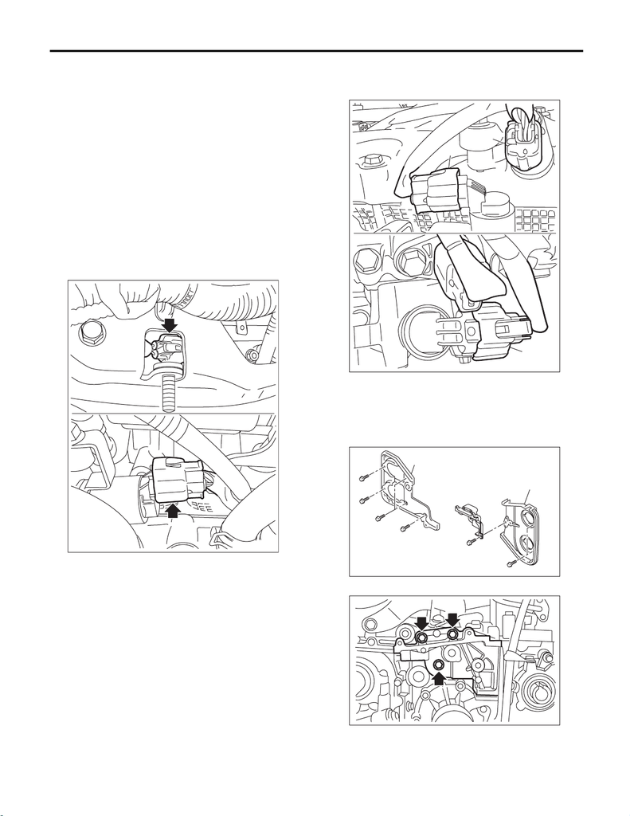

ME(STI)-62

Camshaft

MECHANICAL

18.Camshaft

A: REMOVAL

1) Remove the engine from the vehicle. <Ref. to

ME(STI)-30, REMOVAL, Engine Assembly.>

2) Remove the rear side belt. <Ref. to ME(STI)-41,

REAR SIDE BELT, REMOVAL, V-belt.>

3) Remove the crank pulley. <Ref. to ME(STI)-48,

REMOVAL, Crank Pulley.>

4) Remove the timing belt cover. <Ref. to ME(STI)-

50, REMOVAL, Timing Belt Cover.>

5) Remove the timing belt. <Ref. to ME(STI)-51,

REMOVAL, Timing Belt.>

6) Remove the cam sprocket. <Ref. to ME(STI)-60,

REMOVAL, Cam Sprocket.>

7) Disconnect the connector from the intake oil flow

control solenoid valve.

8) Disconnect the connector (A) from the exhaust

camshaft position sensor and the connector (B)

form the exhaust oil flow control solenoid valve.

9) Remove the timing belt cover No. 2 RH (A) and

timing belt cover No. 2 LH (B).

NOTE:

When removing the timing belt cover, be careful not

to damage the seal rubber.

10) Remove the tensioner bracket.

ME-05990

ME-05025

(B)

(B)

(A)

(A)

ME-04836

(B)

(A)

ME-04984

15WRX_STI_US_EN.book 62 ページ ２０１５年２月１３日 金曜日 午前１１時２０分

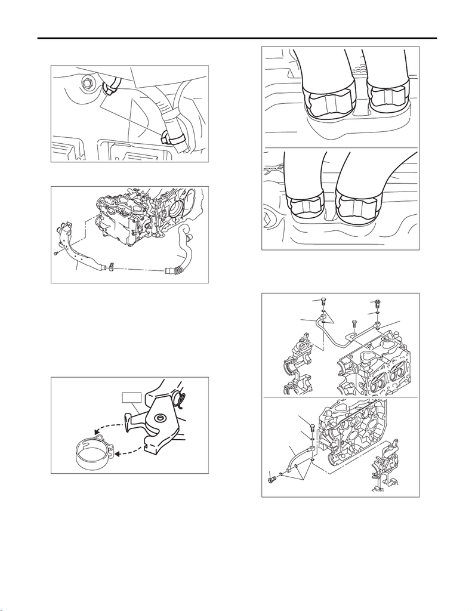

ME(STI)-63

Camshaft

MECHANICAL

11) Remove the clip (A) which hold the engine har-

ness to the rocker cover RH.

12) Remove the air duct B (B) from the rocker cov-

er LH and the air duct A (A).

13) Remove the ignition coil. <Ref. to IG(STI)-7,

REMOVAL, Ignition Coil.>

14) Disconnect PCV hose (A) and vacuum hose

(B) from the rocker cover.

NOTE:

Pinch the clamp by fitting the cut out in the ST with

the protrusion on the clamp as shown in the figure,

and unlock the clamp.

ST 18353AA000 CLAMP PLIERS

15) Remove the rocker cover.

16) Remove the union bolt without filter (without

protrusion) which secures the oil pipe to the front

camshaft cap.

ME-05041

(A)

ME-04953

(B)

(A)

ME-04374

ST

(A) Union bolt with filter (with protrusion)

(B) Union bolt without filter (without protrusion)

(C) Oil pipe RH

(D) Oil pipe LH

(E) Gasket

ME-07960

(A)

(A)

(B)

(B)

ME-05030

(A)

(B)

(D)

(A)

(B)

(C)

(E)

(E)

(E)

(E)

(E)

15WRX_STI_US_EN.book 63 ページ ２０１５年２月１３日 金曜日 午前１１時２０分

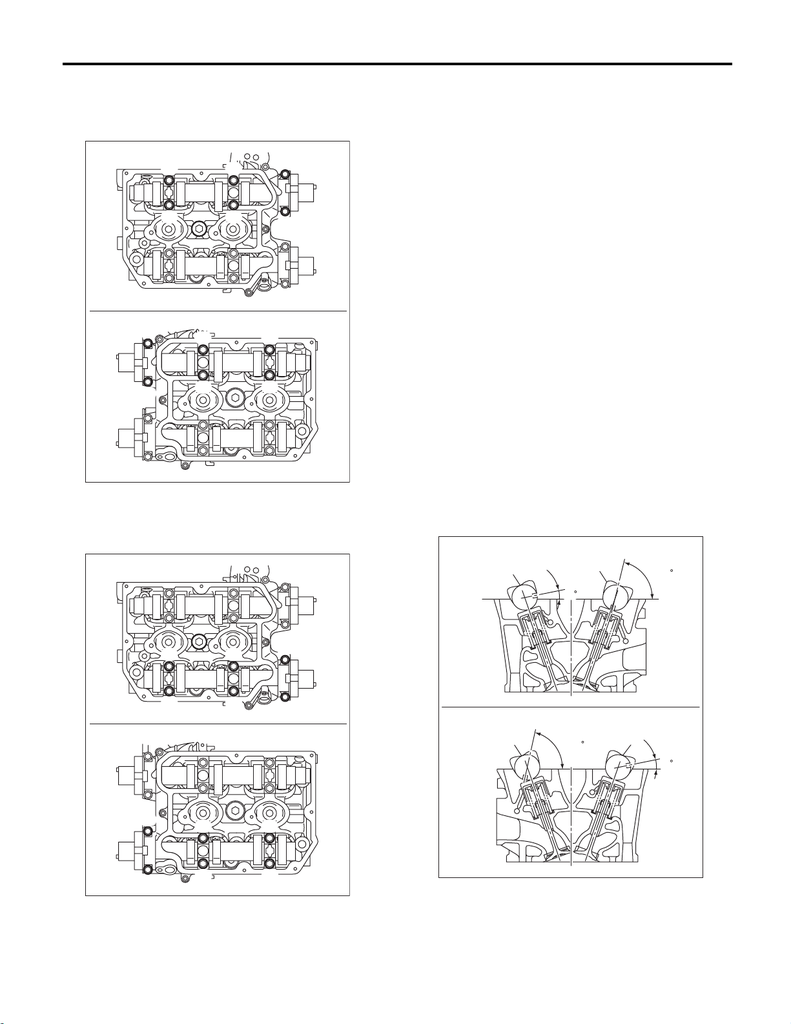

ME(STI)-64

Camshaft

MECHANICAL

17) Loosen the upper side of the front camshaft

cap and the intake camshaft cap bolts equally, a lit-

tle at a time in alphabetical sequence shown in the

figure.

18) Loosen the lower side of the front camshaft cap

and the exhaust camshaft cap bolts equally, a little

at a time in alphabetical sequence shown in the fig-

ure.

19) Remove the front camshaft cap.

20) Remove the intake camshaft caps and intake

camshaft.

21) Remove the exhaust camshaft caps and ex-

haust camshaft.

NOTE:

Arrange camshaft caps in order so that they can be

installed in their original positions.

22) Remove the oil seal.

CAUTION:

Do not scratch the journal surface when remov-

ing the oil seal.

B: INSTALLATION

1) Install the camshaft.

Apply engine oil to the cylinder head at camshaft

journal installation location before installing the cam-

shaft. Install the camshaft so that each valve is close

to or in contact with base circle of the cam lobe.

NOTE:

• Set the camshaft to the position shown in the fig-

ure.

• When set at the position shown in the figure, it is

not necessary to rotate the camshaft RH when in-

stalling the timing belt, but it is necessary to rotate

the camshaft LH slightly.

Intake camshaft LH:

Rotate 80° clockwise.

Exhaust camshaft LH:

Rotate 45° counterclockwise.

ME-05978

(A)

(B)

(A)

(E)

(F)

(B)

(D)

(C)

(E)

(F)

(D)

(C)

ME-05979

(A)

(B)

(E)

(F)

(D)

(C)

(A)

(E)

(F)

(B)

(D)

(C)

(A) Cylinder head RH

(B) Cylinder head LH

(a) Intake camshaft

(b) Exhaust camshaft

ME-05038

(B)

(A)

(a)

(b)

11

77.5

(b)

(a)

77.5

11

15WRX_STI_US_EN.book 64 ページ ２０１５年２月１３日 金曜日 午前１１時２０分

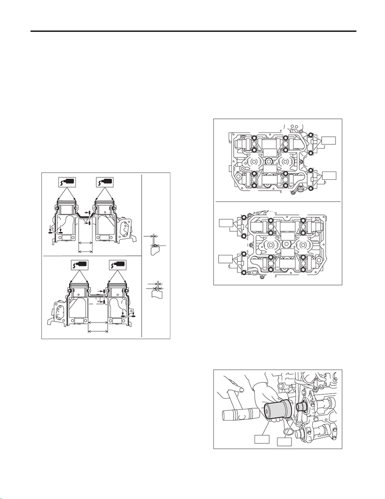

ME(STI)-65

Camshaft

MECHANICAL

2) Install the camshaft cap.

(1) Apply small amount of liquid gasket to the

mating surface of cap.

NOTE:

• Install within 5 min. after applying liquid gasket.

• Do not apply liquid gasket excessively. Applying

excessively may cause excess gasket to come out

and flow toward oil seal, resulting in oil leak.

Liquid gasket:

THREE BOND 1217G (Part No. K0877Y0100)

or equivalent

Liquid gasket applying diameter:

Mating surfaces other than ranges A and B

2

±

0.5 mm (0.0787

±

0.0197 in)

Mating surfaces of ranges A and B

3

±

1 mm (0.1181

±

0.0394 in)

(2) Apply a thin coat of engine oil to the cap

journal surface, and install the camshaft cap to

the camshaft.

(3) Gradually tighten the camshaft cap in at

least two steps, in alphabetical order shown in

the figure, and then tighten to the specified

torque.

Tightening torque:

T1: 9.75 N·m (1.0 kgf-m, 7.2 ft-lb)

T2: 20 N·m (2.0 kgf-m, 14.8 ft-lb)

(4) After tightening the camshaft cap, ensure

the camshaft rotates only slightly while holding

it at base circle.

3) Apply a thin coat of engine oil to the periphery of

the camshaft oil seal and oil seal lip, and install the

oil seal on the camshaft using ST1 and ST2.

NOTE:

Use a new oil seal.

ST1 499587600 OIL SEAL INSTALLER

ST2 499597200 OIL SEAL GUIDE

(A) Range A

(B) Range B

(C) Liquid gasket applying position of mating sur-

faces of ranges other than A and B

(D) Liquid gasket applying position of mating sur-

faces of ranges A and B

(E) 44.8 mm (1.7638 in)

(F) 65 mm (2.5591 in)

(G) φ2±0.5 mm (0.0787±0.0197 in)

(H) 0.5±0.5 mm (0.0197±0.0197 in)

(I) φ3±1 mm (0.1181±0.0394 in)

(J) 1 mm (0.0394 in) or less

ME-05769

(J)

(I)

(B)

(F)

AA

B

B

B

(A)

(E)

AA

B

B-B

(D)

A-A

(C)

(G)

(H)

ME-05980

(G)

(E)

(C)

(A)

(K)

(L)

(J)

(I)

(B)

(D)

(H)

(F)

(G)

(E)

(C)

(A)

(K)

(L)

(J)

(I)

(B)

(D)

(H)

(F)

T1

T2

T1

T2

T2

T2

T1

T1

ME-05002

ST1

ST2

15WRX_STI_US_EN.book 65 ページ ２０１５年２月１３日 金曜日 午前１１時２０分

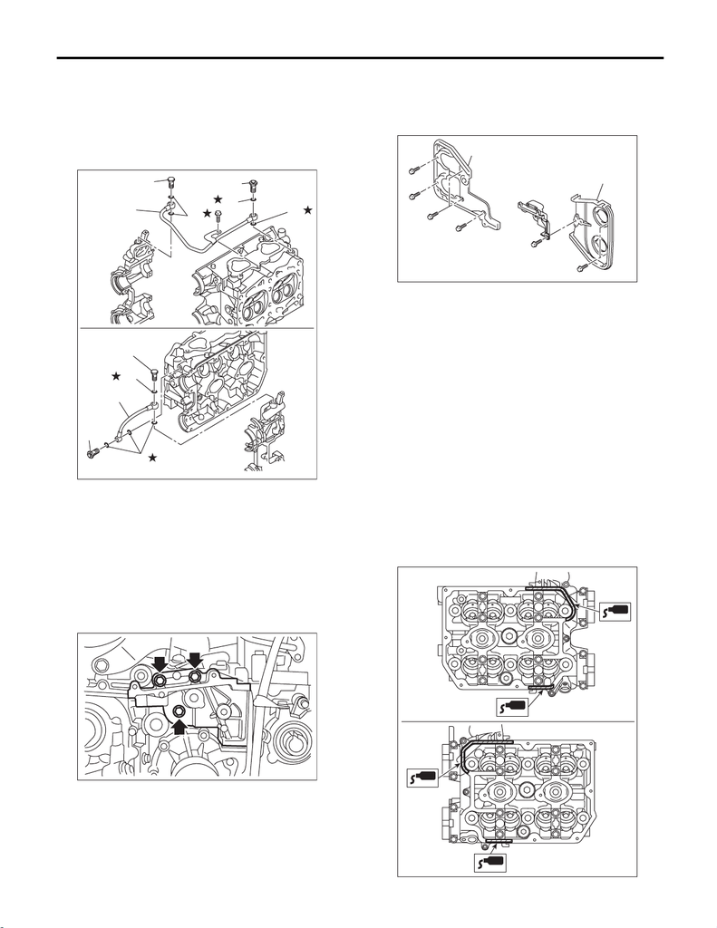

ME(STI)-66

Camshaft

MECHANICAL

4) Install the oil pipe to the front camshaft cap using

the union bolt without filter (without protrusion).

NOTE:

Use a new gasket.

Tightening torque:

29 N·m (3.0 kgf-m, 21.4 ft-lb)

5) Install the tensioner bracket.

Tightening torque:

24.5 N·m (2.5 kgf-m, 18.1 ft-lb)

6) Install the timing belt cover No. 2 RH (A) and tim-

ing belt cover No. 2 LH (B).

Tightening torque:

5 N·m (0.5 kgf-m, 3.7 ft-lb)

7) Install the cam sprocket. <Ref. to ME(STI)-60,

INSTALLATION, Cam Sprocket.>

8) Install the timing belt. <Ref. to ME(STI)-53, IN-

STALLATION, Timing Belt.>

9) Adjust the valve clearance. <Ref. to ME(STI)-29,

ADJUSTMENT, Valve Clearance.>

10) Install the rocker cover.

(1) Install the rocker cover gasket to the rocker

cover. (outer section and ignition coil section)

NOTE:

Use a new rocker cover gasket.

(2) Apply liquid gasket to the specified point of

the cylinder head.

NOTE:

Install within 5 min. after applying liquid gasket.

Liquid gasket:

THREE BOND 1217G (Part No. K0877Y0100)

or equivalent

(A) Union bolt with filter (with protrusion)

(B) Union bolt without filter (without protrusion)

(C) Oil pipe RH

(D) Oil pipe LH

(E) Gasket

ME-05033

(A)

(B)

(D)

(A)

(B)

(C)

(E)

(E)

(E)

(E)

(E)

ME-04984

ME-04836

(B)

(A)

ME-05981

15WRX_STI_US_EN.book 66 ページ ２０１５年２月１３日 金曜日 午前１１時２０分

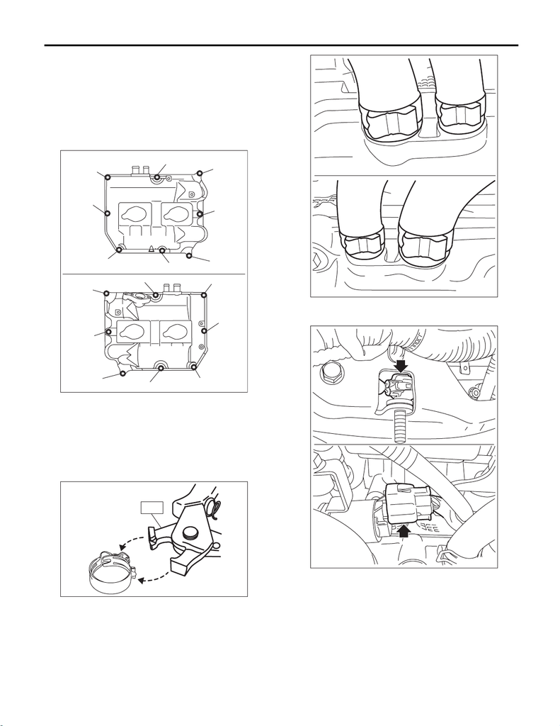

ME(STI)-67

Camshaft

MECHANICAL

(3) Install the rocker cover onto cylinder heads.

Ensure the gasket is properly positioned during

installation.

(4) Temporarily tighten the rocker cover bolts in

alphabetical order shown in the figure, and then

tighten to specified torque in alphabetical order.

Tightening torque:

6.4 N·m (0.7 kgf-m, 4.7 ft-lb)

11) Connect the PCV hose (A) and vacuum hose

(B) to the rocker cover.

NOTE:

Use a new clamp, fit the cut out in the ST with the

protrusion on the clamp as shown in the figure, and

lock the clamp.

ST 18353AA000 CLAMP PLIERS

12) Connect the connector to the intake oil flow

control solenoid valve.

ME-05982

(E)

(F)

(H)

(G)

(D),(L)

(A),(I)

(C),(K)

(B),(J)

(B),(J)

(H)

(F)

(C),(K)

(E)

(A),(I)

(D),(L)

(G)

ME-08033

ST

ME-07960

(A)

(A)

(B)

(B)

ME-05990

15WRX_STI_US_EN.book 67 ページ ２０１５年２月１３日 金曜日 午前１１時２０分

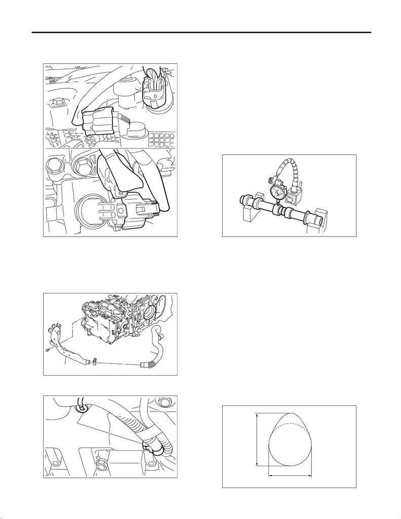

ME(STI)-68

Camshaft

MECHANICAL

13) Connect the connector (A) to the exhaust cam-

shaft position sensor and the connector (B) to the

exhaust oil flow control solenoid valve.

14) Install the ignition coil. <Ref. to IG(STI)-7, IN-

STALLATION, Ignition Coil.>

15) Install the air duct B (B) to the rocker cover LH

and the air duct A (A).

Tightening torque:

6.4 N·m (0.7 kgf-m, 4.7 ft-lb)

16) Fix the engine harness to the rocker cover RH

with clips (A).

17) Install the timing belt cover. <Ref. to ME(STI)-

50, INSTALLATION, Timing Belt Cover.>

18) Install the crank pulley. <Ref. to ME(STI)-48,

INSTALLATION, Crank Pulley.>

19) Install the rear side belt. <Ref. to ME(STI)-42,

REAR SIDE BELT, INSTALLATION, V-belt.>

20) Install the engine to the vehicle. <Ref. to

ME(STI)-34, INSTALLATION, Engine Assembly.>

C: INSPECTION

1) Measure the bend, and repair or replace if nec-

essary.

Camshaft bend limit:

0.020 mm (0.00079 in)

2) Check the journal for damage and wear. Re-

place if faulty.

3) Check the cutout portion used for camshaft sen-

sor for damage. Replace if faulty.

4) Check the cam face condition, and remove the

minor faults by grinding with oil stone. If offset wear

occurs, replace it.

5) Measure the cam lobe height “H” and cam base

circle diameter “A”. If it exceeds the standard or off-

set wear occurs, replace it.

Cam lobe height H:

Standard

Intake

46.55 — 46.65 mm (1.833 — 1.837 in)

Exhaust

46.75 — 46.85 mm (1.841 — 1.844 in)

Cam base circle diameter A:

Standard

37.0 mm (1.457 in)

ME-05025

(B)

(B)

(A)

(A)

ME-04953

(B)

(A)

ME-04952

(A)

ME-00118

ME-00276

H

A

15WRX_STI_US_EN.book 68 ページ ２０１５年２月１３日 金曜日 午前１１時２０分

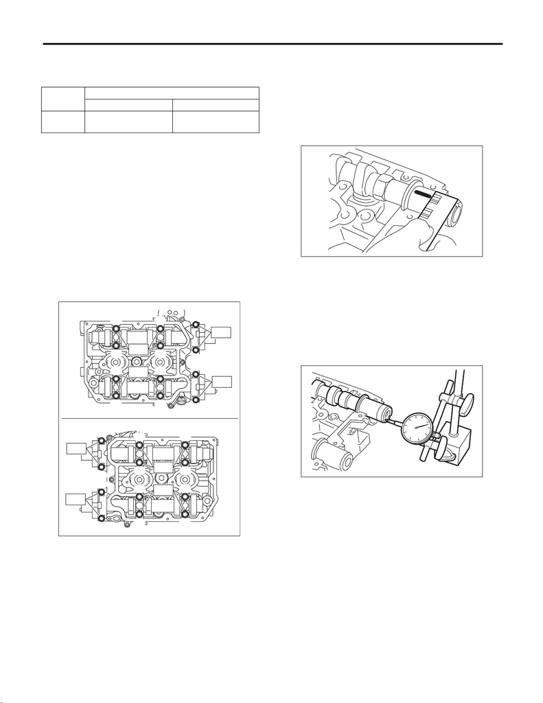

ME(STI)-69

Camshaft

MECHANICAL

6) Measure the outside diameter of camshaft jour-

nal. If the journal diameter is not within specifica-

tion, check the oil clearance.

7) Measure the oil clearance of camshaft journal.

(1) Clean the camshaft cap and cylinder head

camshaft journal.

(2) Place the camshaft on cylinder head. (With-

out installing the valve lifter)

(3) Place a plastigauge across each camshaft

journals.

(4) Gradually tighten the camshaft cap in at

least two steps, in alphabetical order shown in

the figure, and then tighten to the specified

torque. Do not turn the camshaft.

Tightening torque:

T1: 9.75 N·m (1.0 kgf-m, 7.2 ft-lb)

T2: 20 N·m (2.0 kgf-m, 14.8 ft-lb)

(5) Remove the camshaft cap.

(6) Measure the widest point of the plastigauge

on each journal. If oil clearance exceeds the

standard, replace the camshaft. If necessary,

replace the camshaft caps and cylinder head as

a set.

Camshaft oil clearance:

Standard

0.037 — 0.072 mm (0.0015 — 0.0028 in)

(7) Completely remove the plastigauge.

8) Measure the thrust clearance with setting the

dial gauge at end surface of camshaft. If the thrust

clearance is not within the standard or there is off-

set wear, replace the camshaft caps and cylinder

head as a set. If necessary replace the camshaft.

Camshaft thrust clearance:

Standard

0.068 — 0.116 mm (0.0027 — 0.0047 in)

Camshaft journal

Front Center, rear

Standard

mm (in)

37.946 — 37.963

(1.4939 — 1.4946)

29.946 — 29.963

(1.1790 — 1.1796)

ME-05980

(G)

(E)

(C)

(A)

(K)

(L)

(J)

(I)

(B)

(D)

(H)

(F)

(G)

(E)

(C)

(A)

(K)

(L)

(J)

(I)

(B)

(D)

(H)

(F)

T1

T2

T1

T2

T2

T2

T1

T1

ME-00119

ME-00121

15WRX_STI_US_EN.book 69 ページ ２０１５年２月１３日 金曜日 午前１１時２０分